# Risk Factor Analysis

## Outcome Variable

**Outcome Variable:** stunted

## Predictor Variables

**Intervention Variable:** feducyrs

**Adjustment Set:**

- arm
- W_mage
- meducyrs
- hhwealth_quart
- W_mhtcm
- W_gagebrth
- W_birthwt
- W_birthlen
- single
- delta_W_mage
- delta_meducyrs
- delta_hhwealth_quart
- delta_W_mhtcm
- delta_W_gagebrth
- delta_W_birthwt
- delta_W_birthlen
- delta_single

## Stratifying Variables

The analysis was stratified on these variable(s):

- agecat
- studyid
- country

## Data Summary

| agecat | studyid | country | feducyrs | stunted | n_cell | n |
| --- | --- | --- | --- | --- | --- | --- |
| Birth | ki0047075b-MAL-ED | BANGLADESH | Q4 | 0 | 44 | 144 |
| Birth | ki0047075b-MAL-ED | BANGLADESH | Q4 | 1 | 8 | 144 |
| Birth | ki0047075b-MAL-ED | BANGLADESH | Q1 | 0 | 24 | 144 |
| Birth | ki0047075b-MAL-ED | BANGLADESH | Q1 | 1 | 5 | 144 |
| Birth | ki0047075b-MAL-ED | BANGLADESH | Q2 | 0 | 6 | 144 |
| Birth | ki0047075b-MAL-ED | BANGLADESH | Q2 | 1 | 3 | 144 |
| Birth | ki0047075b-MAL-ED | BANGLADESH | Q3 | 0 | 44 | 144 |
| Birth | ki0047075b-MAL-ED | BANGLADESH | Q3 | 1 | 10 | 144 |
| 6 months | ki0047075b-MAL-ED | BANGLADESH | Q4 | 0 | 44 | 132 |
| 6 months | ki0047075b-MAL-ED | BANGLADESH | Q4 | 1 | 6 | 132 |
| 6 months | ki0047075b-MAL-ED | BANGLADESH | Q1 | 0 | 24 | 132 |
| 6 months | ki0047075b-MAL-ED | BANGLADESH | Q1 | 1 | 5 | 132 |
| 6 months | ki0047075b-MAL-ED | BANGLADESH | Q2 | 0 | 5 | 132 |
| 6 months | ki0047075b-MAL-ED | BANGLADESH | Q2 | 1 | 2 | 132 |
| 6 months | ki0047075b-MAL-ED | BANGLADESH | Q3 | 0 | 39 | 132 |
| 6 months | ki0047075b-MAL-ED | BANGLADESH | Q3 | 1 | 7 | 132 |
| 24 months | ki0047075b-MAL-ED | BANGLADESH | Q4 | 0 | 28 | 117 |
| 24 months | ki0047075b-MAL-ED | BANGLADESH | Q4 | 1 | 12 | 117 |
| 24 months | ki0047075b-MAL-ED | BANGLADESH | Q1 | 0 | 17 | 117 |
| 24 months | ki0047075b-MAL-ED | BANGLADESH | Q1 | 1 | 12 | 117 |
| 24 months | ki0047075b-MAL-ED | BANGLADESH | Q2 | 0 | 4 | 117 |
| 24 months | ki0047075b-MAL-ED | BANGLADESH | Q2 | 1 | 2 | 117 |
| 24 months | ki0047075b-MAL-ED | BANGLADESH | Q3 | 0 | 20 | 117 |
| 24 months | ki0047075b-MAL-ED | BANGLADESH | Q3 | 1 | 22 | 117 |
| Birth | ki0047075b-MAL-ED | INDIA | Q4 | 0 | 32 | 123 |
| Birth | ki0047075b-MAL-ED | INDIA | Q4 | 1 | 6 | 123 |
| Birth | ki0047075b-MAL-ED | INDIA | Q1 | 0 | 20 | 123 |
| Birth | ki0047075b-MAL-ED | INDIA | Q1 | 1 | 1 | 123 |
| Birth | ki0047075b-MAL-ED | INDIA | Q2 | 0 | 33 | 123 |
| Birth | ki0047075b-MAL-ED | INDIA | Q2 | 1 | 4 | 123 |

[output cut: 388 more lines]

The following strata were considered:

- agecat: 24 months, studyid: ki0047075b-MAL-ED, country: BANGLADESH
- agecat: 24 months, studyid: ki0047075b-MAL-ED, country: INDIA
- agecat: 24 months, studyid: ki0047075b-MAL-ED, country: NEPAL
- agecat: 24 months, studyid: ki0047075b-MAL-ED, country: PERU
- agecat: 24 months, studyid: ki0047075b-MAL-ED, country: SOUTH AFRICA
- agecat: 24 months, studyid: ki0047075b-MAL-ED, country: TANZANIA, UNITED REPUBLIC OF
- agecat: 24 months, studyid: ki1017093b-PROVIDE, country: BANGLADESH
- agecat: 24 months, studyid: ki1017093c-NIH-Crypto, country: BANGLADESH
- agecat: 24 months, studyid: ki1066203-TanzaniaChild2, country: TANZANIA, UNITED REPUBLIC OF
- agecat: 24 months, studyid: ki1113344-GMS-Nepal, country: NEPAL
- agecat: 24 months, studyid: ki1119695-PROBIT, country: BELARUS
- agecat: 24 months, studyid: ki1126311-ZVITAMBO, country: ZIMBABWE
- agecat: 24 months, studyid: ki1135781-COHORTS, country: GUATEMALA
- agecat: 24 months, studyid: ki1135781-COHORTS, country: INDIA
- agecat: 24 months, studyid: ki1135781-COHORTS, country: PHILIPPINES
- agecat: 24 months, studyid: ki1148112-LCNI-5, country: MALAWI
- agecat: 24 months, studyid: kiGH5241-JiVitA-3, country: BANGLADESH
- agecat: 24 months, studyid: kiGH5241-JiVitA-4, country: BANGLADESH
- agecat: 6 months, studyid: ki0047075b-MAL-ED, country: BANGLADESH
- agecat: 6 months, studyid: ki0047075b-MAL-ED, country: INDIA
- agecat: 6 months, studyid: ki0047075b-MAL-ED, country: NEPAL
- agecat: 6 months, studyid: ki0047075b-MAL-ED, country: PERU
- agecat: 6 months, studyid: ki0047075b-MAL-ED, country: SOUTH AFRICA
- agecat: 6 months, studyid: ki0047075b-MAL-ED, country: TANZANIA, UNITED REPUBLIC OF
- agecat: 6 months, studyid: ki1000304b-SAS-CompFeed, country: INDIA
- agecat: 6 months, studyid: ki1000304b-SAS-FoodSuppl, country: INDIA
- agecat: 6 months, studyid: ki1017093b-PROVIDE, country: BANGLADESH
- agecat: 6 months, studyid: ki1017093c-NIH-Crypto, country: BANGLADESH
- agecat: 6 months, studyid: ki1066203-TanzaniaChild2, country: TANZANIA, UNITED REPUBLIC OF
- agecat: 6 months, studyid: ki1113344-GMS-Nepal, country: NEPAL
- agecat: 6 months, studyid: ki1119695-PROBIT, country: BELARUS
- agecat: 6 months, studyid: ki1126311-ZVITAMBO, country: ZIMBABWE
- agecat: 6 months, studyid: ki1135781-COHORTS, country: GUATEMALA
- agecat: 6 months, studyid: ki1135781-COHORTS, country: INDIA
- agecat: 6 months, studyid: ki1135781-COHORTS, country: PHILIPPINES
- agecat: 6 months, studyid: ki1148112-LCNI-5, country: MALAWI
- agecat: 6 months, studyid: kiGH5241-JiVitA-3, country: BANGLADESH
- agecat: 6 months, studyid: kiGH5241-JiVitA-4, country: BANGLADESH
- agecat: Birth, studyid: ki0047075b-MAL-ED, country: BANGLADESH
- agecat: Birth, studyid: ki0047075b-MAL-ED, country: INDIA
- agecat: Birth, studyid: ki0047075b-MAL-ED, country: NEPAL
- agecat: Birth, studyid: ki0047075b-MAL-ED, country: PERU
- agecat: Birth, studyid: ki0047075b-MAL-ED, country: SOUTH AFRICA
- agecat: Birth, studyid: ki0047075b-MAL-ED, country: TANZANIA, UNITED REPUBLIC OF
- agecat: Birth, studyid: ki1000304b-SAS-CompFeed, country: INDIA
- agecat: Birth, studyid: ki1017093c-NIH-Crypto, country: BANGLADESH
- agecat: Birth, studyid: ki1119695-PROBIT, country: BELARUS
- agecat: Birth, studyid: ki1126311-ZVITAMBO, country: ZIMBABWE
- agecat: Birth, studyid: ki1135781-COHORTS, country: GUATEMALA
- agecat: Birth, studyid: ki1135781-COHORTS, country: INDIA
- agecat: Birth, studyid: ki1135781-COHORTS, country: PHILIPPINES
- agecat: Birth, studyid: kiGH5241-JiVitA-3, country: BANGLADESH
- agecat: Birth, studyid: kiGH5241-JiVitA-4, country: BANGLADESH

### Dropped Strata

Some strata were dropped due to rare outcomes:

- agecat: Birth, studyid: ki0047075b-MAL-ED, country: BANGLADESH
- agecat: 6 months, studyid: ki0047075b-MAL-ED, country: BANGLADESH
- agecat: 24 months, studyid: ki0047075b-MAL-ED, country: BANGLADESH
- agecat: Birth, studyid: ki0047075b-MAL-ED, country: INDIA
- agecat: 6 months, studyid: ki0047075b-MAL-ED, country: INDIA
- agecat: 6 months, studyid: ki0047075b-MAL-ED, country: NEPAL
- agecat: 24 months, studyid: ki0047075b-MAL-ED, country: NEPAL
- agecat: Birth, studyid: ki0047075b-MAL-ED, country: NEPAL
- agecat: Birth, studyid: ki0047075b-MAL-ED, country: PERU
- agecat: 6 months, studyid: ki0047075b-MAL-ED, country: PERU
- agecat: 24 months, studyid: ki0047075b-MAL-ED, country: PERU
- agecat: Birth, studyid: ki0047075b-MAL-ED, country: SOUTH AFRICA
- agecat: 6 months, studyid: ki0047075b-MAL-ED, country: SOUTH AFRICA
- agecat: Birth, studyid: ki0047075b-MAL-ED, country: TANZANIA, UNITED REPUBLIC OF
- agecat: 6 months, studyid: ki0047075b-MAL-ED, country: TANZANIA, UNITED REPUBLIC OF
- agecat: 24 months, studyid: ki0047075b-MAL-ED, country: TANZANIA, UNITED REPUBLIC OF
- agecat: Birth, studyid: ki1000304b-SAS-CompFeed, country: INDIA
- agecat: 6 months, studyid: ki1017093b-PROVIDE, country: BANGLADESH
- agecat: 24 months, studyid: ki1017093b-PROVIDE, country: BANGLADESH
- agecat: Birth, studyid: ki1017093c-NIH-Crypto, country: BANGLADESH
- agecat: 6 months, studyid: ki1066203-TanzaniaChild2, country: TANZANIA, UNITED REPUBLIC OF
- agecat: 24 months, studyid: ki1066203-TanzaniaChild2, country: TANZANIA, UNITED REPUBLIC OF
- agecat: Birth, studyid: ki1119695-PROBIT, country: BELARUS
- agecat: 24 months, studyid: ki1119695-PROBIT, country: BELARUS
- agecat: 24 months, studyid: ki1126311-ZVITAMBO, country: ZIMBABWE
- agecat: 6 months, studyid: ki1135781-COHORTS, country: GUATEMALA
- agecat: 24 months, studyid: ki1135781-COHORTS, country: GUATEMALA
- agecat: Birth, studyid: ki1135781-COHORTS, country: GUATEMALA
- agecat: 6 months, studyid: kiGH5241-JiVitA-4, country: BANGLADESH
- agecat: Birth, studyid: kiGH5241-JiVitA-4, country: BANGLADESH

## Methods Detail

We’re interested in the causal parameters $E[Y_a]$ for all values of $a \in \mathcal{A}$. These parameters represent the mean outcome if, possibly contrary to fact, we intervened to set all units to have $A=a$. Under the randomization and positivity assumptions, these are identified by the statistical parameters $\psi_a=E_W[E_{Y|A,W}(Y|A=a,W)]$. In addition, we’re interested in the mean of $Y$, $E[Y]$ under no intervention (the observed mean). We will estimate these parameters by using SuperLearner to fit the relevant likelihood factors – $E_{Y|A,W}(Y|A=a,W)$ and $p(A=a|W)$, and then updating our likelihood fit using a joint TMLE.

For unadjusted analyses ($W=\{\}$), initial likelihoods were estimated using Lrnr_glm to estimate the simple $E(Y|A)$ and Lrnr_mean to estimate $p(A)$. For adjusted analyses, a small library containing Lrnr_glmnet, Lrnr_xgboost, and Lrnr_mean was used.

Having estimated these parameters, we will then use the delta method to estimate relative risks and attributable risks relative to a prespecified baseline level of $A$.

# Results Detail

## Results Plots

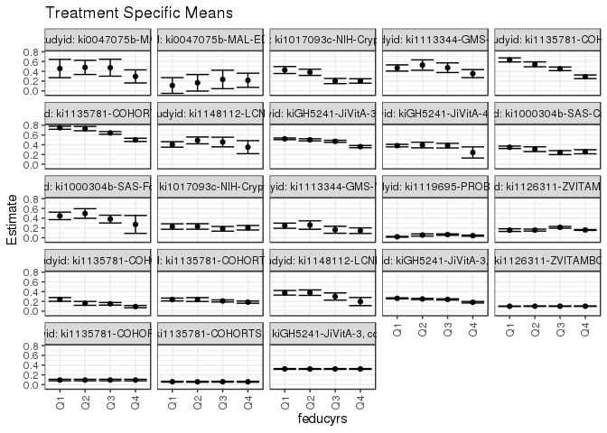

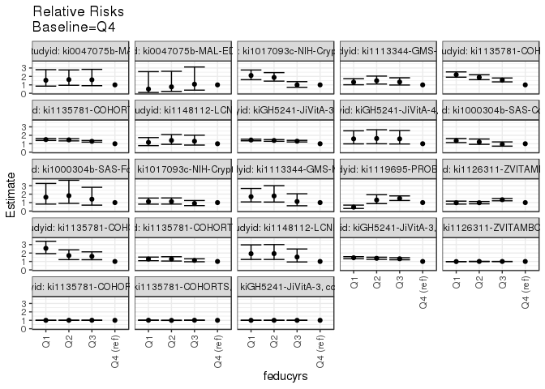

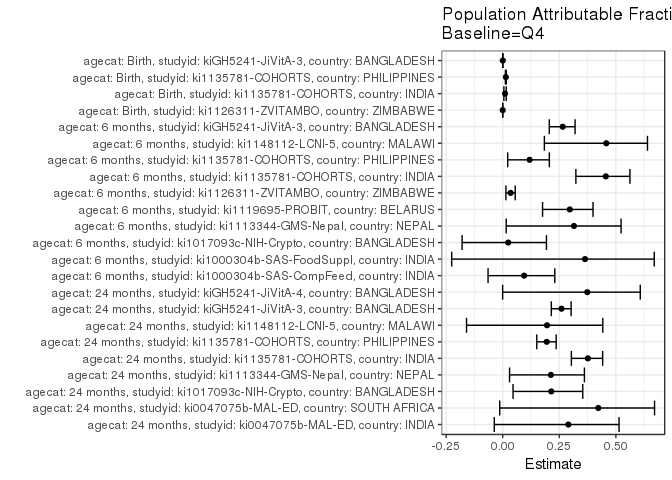

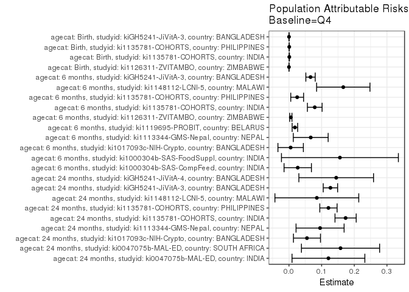

## Results Table

### Parameter: TSM

| agecat | studyid | country | intervention_level | baseline_level | estimate | ci_lower | ci_upper |
| --- | --- | --- | --- | --- | --- | --- | --- |
| Birth | ki1126311-ZVITAMBO | ZIMBABWE | Q4 | NA | 0.1029647 | 0.0978307 | 0.1080987 |
| Birth | ki1126311-ZVITAMBO | ZIMBABWE | Q1 | NA | 0.1013925 | 0.0963387 | 0.1064462 |
| Birth | ki1126311-ZVITAMBO | ZIMBABWE | Q2 | NA | 0.1031212 | 0.0979962 | 0.1082461 |
| Birth | ki1126311-ZVITAMBO | ZIMBABWE | Q3 | NA | 0.1029451 | 0.0978143 | 0.1080758 |
| Birth | ki1135781-COHORTS | INDIA | Q4 | NA | 0.0942859 | 0.0787890 | 0.1097827 |
| Birth | ki1135781-COHORTS | INDIA | Q1 | NA | 0.0942987 | 0.0788074 | 0.1097900 |
| Birth | ki1135781-COHORTS | INDIA | Q2 | NA | 0.0945640 | 0.0790258 | 0.1101022 |
| Birth | ki1135781-COHORTS | INDIA | Q3 | NA | 0.0949634 | 0.0793677 | 0.1105591 |
| Birth | ki1135781-COHORTS | PHILIPPINES | Q4 | NA | 0.0593848 | 0.0507999 | 0.0679698 |
| Birth | ki1135781-COHORTS | PHILIPPINES | Q1 | NA | 0.0599774 | 0.0513069 | 0.0686479 |
| Birth | ki1135781-COHORTS | PHILIPPINES | Q2 | NA | 0.0590090 | 0.0504706 | 0.0675473 |
| Birth | ki1135781-COHORTS | PHILIPPINES | Q3 | NA | 0.0600342 | 0.0513579 | 0.0687104 |
| Birth | kiGH5241-JiVitA-3 | BANGLADESH | Q4 | NA | 0.3216940 | 0.3139217 | 0.3294663 |
| Birth | kiGH5241-JiVitA-3 | BANGLADESH | Q1 | NA | 0.3218497 | 0.3140729 | 0.3296266 |
| Birth | kiGH5241-JiVitA-3 | BANGLADESH | Q2 | NA | 0.3218275 | 0.3140511 | 0.3296039 |
| Birth | kiGH5241-JiVitA-3 | BANGLADESH | Q3 | NA | 0.3218151 | 0.3140393 | 0.3295909 |
| 6 months | ki1000304b-SAS-CompFeed | INDIA | Q4 | NA | 0.2567166 | 0.2144023 | 0.2990308 |
| 6 months | ki1000304b-SAS-CompFeed | INDIA | Q1 | NA | 0.3481894 | 0.3235672 | 0.3728117 |
| 6 months | ki1000304b-SAS-CompFeed | INDIA | Q2 | NA | 0.3093082 | 0.2610628 | 0.3575536 |
| 6 months | ki1000304b-SAS-CompFeed | INDIA | Q3 | NA | 0.2391545 | 0.1981717 | 0.2801373 |
| 6 months | ki1000304b-SAS-FoodSuppl | INDIA | Q4 | NA | 0.2729241 | 0.0898699 | 0.4559783 |
| 6 months | ki1000304b-SAS-FoodSuppl | INDIA | Q1 | NA | 0.4475815 | 0.3705156 | 0.5246474 |
| 6 months | ki1000304b-SAS-FoodSuppl | INDIA | Q2 | NA | 0.4964532 | 0.3980818 | 0.5948246 |
| 6 months | ki1000304b-SAS-FoodSuppl | INDIA | Q3 | NA | 0.3825662 | 0.3031313 | 0.4620010 |
| 6 months | ki1017093c-NIH-Crypto | BANGLADESH | Q4 | NA | 0.2046333 | 0.1585327 | 0.2507339 |
| 6 months | ki1017093c-NIH-Crypto | BANGLADESH | Q1 | NA | 0.2293118 | 0.1731305 | 0.2854931 |
| 6 months | ki1017093c-NIH-Crypto | BANGLADESH | Q2 | NA | 0.2310663 | 0.1749081 | 0.2872246 |
| 6 months | ki1017093c-NIH-Crypto | BANGLADESH | Q3 | NA | 0.1834697 | 0.1352877 | 0.2316516 |
| 6 months | ki1113344-GMS-Nepal | NEPAL | Q4 | NA | 0.1450918 | 0.0870865 | 0.2030971 |
| 6 months | ki1113344-GMS-Nepal | NEPAL | Q1 | NA | 0.2463655 | 0.1932981 | 0.2994328 |

[output cut: 62 more lines]

### Parameter: E(Y)

| agecat | studyid | country | intervention_level | baseline_level | estimate | ci_lower | ci_upper |
| --- | --- | --- | --- | --- | --- | --- | --- |
| Birth | ki1126311-ZVITAMBO | ZIMBABWE | NA | NA | 0.1029718 | 0.0978372 | 0.1081063 |
| Birth | ki1135781-COHORTS | INDIA | NA | NA | 0.0952733 | 0.0796294 | 0.1109171 |
| Birth | ki1135781-COHORTS | PHILIPPINES | NA | NA | 0.0602158 | 0.0515157 | 0.0689159 |
| Birth | kiGH5241-JiVitA-3 | BANGLADESH | NA | NA | 0.3218470 | 0.3140700 | 0.3296240 |
| 6 months | ki1000304b-SAS-CompFeed | INDIA | NA | NA | 0.2835709 | 0.2656121 | 0.3015297 |
| 6 months | ki1000304b-SAS-FoodSuppl | INDIA | NA | NA | 0.4289474 | 0.3791199 | 0.4787748 |
| 6 months | ki1017093c-NIH-Crypto | BANGLADESH | NA | NA | 0.2097902 | 0.1799252 | 0.2396552 |
| 6 months | ki1113344-GMS-Nepal | NEPAL | NA | NA | 0.2117438 | 0.1779368 | 0.2455507 |
| 6 months | ki1119695-PROBIT | BELARUS | NA | NA | 0.0613372 | 0.0479409 | 0.0747335 |
| 6 months | ki1126311-ZVITAMBO | ZIMBABWE | NA | NA | 0.1645789 | 0.1564849 | 0.1726730 |
| 6 months | ki1135781-COHORTS | INDIA | NA | NA | 0.1732852 | 0.1533446 | 0.1932258 |
| 6 months | ki1135781-COHORTS | PHILIPPINES | NA | NA | 0.2113885 | 0.1955816 | 0.2271953 |
| 6 months | ki1148112-LCNI-5 | MALAWI | NA | NA | 0.3633005 | 0.3301997 | 0.3964012 |
| 6 months | kiGH5241-JiVitA-3 | BANGLADESH | NA | NA | 0.2491941 | 0.2409375 | 0.2574508 |
| 24 months | ki0047075b-MAL-ED | INDIA | NA | NA | 0.4166667 | 0.3322428 | 0.5010905 |
| 24 months | ki0047075b-MAL-ED | SOUTH AFRICA | NA | NA | 0.3736264 | 0.2736811 | 0.4735717 |
| 24 months | ki1017093c-NIH-Crypto | BANGLADESH | NA | NA | 0.2568093 | 0.2190047 | 0.2946140 |
| 24 months | ki1113344-GMS-Nepal | NEPAL | NA | NA | 0.4477912 | 0.4040733 | 0.4915091 |
| 24 months | ki1135781-COHORTS | INDIA | NA | NA | 0.4608696 | 0.4345607 | 0.4871784 |
| 24 months | ki1135781-COHORTS | PHILIPPINES | NA | NA | 0.6214347 | 0.6016683 | 0.6412012 |
| 24 months | ki1148112-LCNI-5 | MALAWI | NA | NA | 0.4360771 | 0.3953670 | 0.4767872 |
| 24 months | kiGH5241-JiVitA-3 | BANGLADESH | NA | NA | 0.4886048 | 0.4753517 | 0.5018580 |
| 24 months | kiGH5241-JiVitA-4 | BANGLADESH | NA | NA | 0.3871566 | 0.3638029 | 0.4105104 |

### Parameter: RR

| agecat | studyid | country | intervention_level | baseline_level | estimate | ci_lower | ci_upper |
| --- | --- | --- | --- | --- | --- | --- | --- |
| Birth | ki1126311-ZVITAMBO | ZIMBABWE | Q4 | Q4 | 1.0000000 | 1.0000000 | 1.0000000 |
| Birth | ki1126311-ZVITAMBO | ZIMBABWE | Q1 | Q4 | 0.9847306 | 0.9841638 | 0.9852978 |
| Birth | ki1126311-ZVITAMBO | ZIMBABWE | Q2 | Q4 | 1.0015197 | 1.0005016 | 1.0025390 |
| Birth | ki1126311-ZVITAMBO | ZIMBABWE | Q3 | Q4 | 0.9998096 | 0.9992658 | 1.0003536 |
| Birth | ki1135781-COHORTS | INDIA | Q4 | Q4 | 1.0000000 | 1.0000000 | 1.0000000 |
| Birth | ki1135781-COHORTS | INDIA | Q1 | Q4 | 1.0001365 | 0.9941910 | 1.0061175 |
| Birth | ki1135781-COHORTS | INDIA | Q2 | Q4 | 1.0029501 | 0.9997025 | 1.0062082 |
| Birth | ki1135781-COHORTS | INDIA | Q3 | Q4 | 1.0071858 | 1.0020186 | 1.0123796 |
| Birth | ki1135781-COHORTS | PHILIPPINES | Q4 | Q4 | 1.0000000 | 1.0000000 | 1.0000000 |
| Birth | ki1135781-COHORTS | PHILIPPINES | Q1 | Q4 | 1.0099781 | 1.0076754 | 1.0122862 |
| Birth | ki1135781-COHORTS | PHILIPPINES | Q2 | Q4 | 0.9936705 | 0.9903872 | 0.9969648 |
| Birth | ki1135781-COHORTS | PHILIPPINES | Q3 | Q4 | 1.0109344 | 1.0086037 | 1.0132706 |
| Birth | kiGH5241-JiVitA-3 | BANGLADESH | Q4 | Q4 | 1.0000000 | 1.0000000 | 1.0000000 |
| Birth | kiGH5241-JiVitA-3 | BANGLADESH | Q1 | Q4 | 1.0004841 | 1.0003897 | 1.0005785 |
| Birth | kiGH5241-JiVitA-3 | BANGLADESH | Q2 | Q4 | 1.0004150 | 1.0003503 | 1.0004798 |
| Birth | kiGH5241-JiVitA-3 | BANGLADESH | Q3 | Q4 | 1.0003764 | 1.0003090 | 1.0004439 |
| 6 months | ki1000304b-SAS-CompFeed | INDIA | Q4 | Q4 | 1.0000000 | 1.0000000 | 1.0000000 |
| 6 months | ki1000304b-SAS-CompFeed | INDIA | Q1 | Q4 | 1.3563187 | 1.1378680 | 1.6167080 |
| 6 months | ki1000304b-SAS-CompFeed | INDIA | Q2 | Q4 | 1.2048627 | 0.9312016 | 1.5589471 |
| 6 months | ki1000304b-SAS-CompFeed | INDIA | Q3 | Q4 | 0.9315899 | 0.7133684 | 1.2165659 |
| 6 months | ki1000304b-SAS-FoodSuppl | INDIA | Q4 | Q4 | 1.0000000 | 1.0000000 | 1.0000000 |
| 6 months | ki1000304b-SAS-FoodSuppl | INDIA | Q1 | Q4 | 1.6399487 | 0.8232230 | 3.2669543 |
| 6 months | ki1000304b-SAS-FoodSuppl | INDIA | Q2 | Q4 | 1.8190158 | 0.9066750 | 3.6493987 |
| 6 months | ki1000304b-SAS-FoodSuppl | INDIA | Q3 | Q4 | 1.4017311 | 0.6981789 | 2.8142504 |
| 6 months | ki1017093c-NIH-Crypto | BANGLADESH | Q4 | Q4 | 1.0000000 | 1.0000000 | 1.0000000 |
| 6 months | ki1017093c-NIH-Crypto | BANGLADESH | Q1 | Q4 | 1.1205984 | 0.8156450 | 1.5395679 |
| 6 months | ki1017093c-NIH-Crypto | BANGLADESH | Q2 | Q4 | 1.1291726 | 0.8212890 | 1.5524751 |
| 6 months | ki1017093c-NIH-Crypto | BANGLADESH | Q3 | Q4 | 0.8965777 | 0.6450880 | 1.2461113 |
| 6 months | ki1113344-GMS-Nepal | NEPAL | Q4 | Q4 | 1.0000000 | 1.0000000 | 1.0000000 |
| 6 months | ki1113344-GMS-Nepal | NEPAL | Q1 | Q4 | 1.6979972 | 1.0780829 | 2.6743718 |

[output cut: 62 more lines]

### Parameter: PAR

| agecat | studyid | country | intervention_level | baseline_level | estimate | ci_lower | ci_upper |
| --- | --- | --- | --- | --- | --- | --- | --- |
| Birth | ki1126311-ZVITAMBO | ZIMBABWE | Q4 | NA | 0.0000071 | -0.0000019 | 0.0000160 |
| Birth | ki1135781-COHORTS | INDIA | Q4 | NA | 0.0009874 | 0.0004671 | 0.0015077 |
| Birth | ki1135781-COHORTS | PHILIPPINES | Q4 | NA | 0.0008310 | 0.0006682 | 0.0009938 |
| Birth | kiGH5241-JiVitA-3 | BANGLADESH | Q4 | NA | 0.0001530 | 0.0001287 | 0.0001773 |
| 6 months | ki1000304b-SAS-CompFeed | INDIA | Q4 | NA | 0.0268543 | -0.0150683 | 0.0687770 |
| 6 months | ki1000304b-SAS-FoodSuppl | INDIA | Q4 | NA | 0.1560233 | -0.0229747 | 0.3350213 |
| 6 months | ki1017093c-NIH-Crypto | BANGLADESH | Q4 | NA | 0.0051569 | -0.0337926 | 0.0441064 |
| 6 months | ki1113344-GMS-Nepal | NEPAL | Q4 | NA | 0.0666520 | 0.0132818 | 0.1200221 |
| 6 months | ki1119695-PROBIT | BELARUS | Q4 | NA | 0.0181802 | 0.0097419 | 0.0266186 |
| 6 months | ki1126311-ZVITAMBO | ZIMBABWE | Q4 | NA | 0.0057429 | 0.0023505 | 0.0091353 |
| 6 months | ki1135781-COHORTS | INDIA | Q4 | NA | 0.0789570 | 0.0564462 | 0.1014678 |
| 6 months | ki1135781-COHORTS | PHILIPPINES | Q4 | NA | 0.0251261 | 0.0054565 | 0.0447957 |
| 6 months | ki1148112-LCNI-5 | MALAWI | Q4 | NA | 0.1663114 | 0.0846394 | 0.2479835 |
| 6 months | kiGH5241-JiVitA-3 | BANGLADESH | Q4 | NA | 0.0660349 | 0.0516722 | 0.0803975 |
| 24 months | ki0047075b-MAL-ED | INDIA | Q4 | NA | 0.1208602 | 0.0093809 | 0.2323396 |
| 24 months | ki0047075b-MAL-ED | SOUTH AFRICA | Q4 | NA | 0.1578803 | 0.0381682 | 0.2775924 |
| 24 months | ki1017093c-NIH-Crypto | BANGLADESH | Q4 | NA | 0.0551160 | 0.0137311 | 0.0965010 |
| 24 months | ki1113344-GMS-Nepal | NEPAL | Q4 | NA | 0.0952833 | 0.0217037 | 0.1688629 |
| 24 months | ki1135781-COHORTS | INDIA | Q4 | NA | 0.1734385 | 0.1409686 | 0.2059084 |
| 24 months | ki1135781-COHORTS | PHILIPPINES | Q4 | NA | 0.1208686 | 0.0943863 | 0.1473510 |
| 24 months | ki1148112-LCNI-5 | MALAWI | Q4 | NA | 0.0853363 | -0.0430325 | 0.2137052 |
| 24 months | kiGH5241-JiVitA-3 | BANGLADESH | Q4 | NA | 0.1269670 | 0.1049536 | 0.1489804 |
| 24 months | kiGH5241-JiVitA-4 | BANGLADESH | Q4 | NA | 0.1446667 | 0.0303481 | 0.2589852 |

### Parameter: PAF

| agecat | studyid | country | intervention_level | baseline_level | estimate | ci_lower | ci_upper |
| --- | --- | --- | --- | --- | --- | --- | --- |
| Birth | ki1126311-ZVITAMBO | ZIMBABWE | Q4 | NA | 0.0000689 | -0.0000179 | 0.0001557 |
| Birth | ki1135781-COHORTS | INDIA | Q4 | NA | 0.0103639 | 0.0051362 | 0.0155640 |
| Birth | ki1135781-COHORTS | PHILIPPINES | Q4 | NA | 0.0137998 | 0.0118989 | 0.0156971 |
| Birth | kiGH5241-JiVitA-3 | BANGLADESH | Q4 | NA | 0.0004754 | 0.0004014 | 0.0005494 |
| 6 months | ki1000304b-SAS-CompFeed | INDIA | Q4 | NA | 0.0947006 | -0.0646757 | 0.2302191 |
| 6 months | ki1000304b-SAS-FoodSuppl | INDIA | Q4 | NA | 0.3637353 | -0.2254379 | 0.6696424 |
| 6 months | ki1017093c-NIH-Crypto | BANGLADESH | Q4 | NA | 0.0245812 | -0.1794467 | 0.1933151 |
| 6 months | ki1113344-GMS-Nepal | NEPAL | Q4 | NA | 0.3147766 | 0.0155170 | 0.5230683 |
| 6 months | ki1119695-PROBIT | BELARUS | Q4 | NA | 0.2963982 | 0.1760981 | 0.3991329 |
| 6 months | ki1126311-ZVITAMBO | ZIMBABWE | Q4 | NA | 0.0348944 | 0.0141782 | 0.0551753 |
| 6 months | ki1135781-COHORTS | INDIA | Q4 | NA | 0.4556477 | 0.3233058 | 0.5621074 |
| 6 months | ki1135781-COHORTS | PHILIPPINES | Q4 | NA | 0.1188623 | 0.0221094 | 0.2060424 |
| 6 months | ki1148112-LCNI-5 | MALAWI | Q4 | NA | 0.4577793 | 0.1840770 | 0.6396679 |
| 6 months | kiGH5241-JiVitA-3 | BANGLADESH | Q4 | NA | 0.2649936 | 0.2058270 | 0.3197523 |
| 24 months | ki0047075b-MAL-ED | INDIA | Q4 | NA | 0.2900646 | -0.0371651 | 0.5140520 |
| 24 months | ki0047075b-MAL-ED | SOUTH AFRICA | Q4 | NA | 0.4225620 | -0.0131687 | 0.6708992 |
| 24 months | ki1017093c-NIH-Crypto | BANGLADESH | Q4 | NA | 0.2146185 | 0.0457121 | 0.3536290 |
| 24 months | ki1113344-GMS-Nepal | NEPAL | Q4 | NA | 0.2127852 | 0.0302191 | 0.3609823 |
| 24 months | ki1135781-COHORTS | INDIA | Q4 | NA | 0.3763289 | 0.3034064 | 0.4416175 |
| 24 months | ki1135781-COHORTS | PHILIPPINES | Q4 | NA | 0.1944993 | 0.1504987 | 0.2362209 |
| 24 months | ki1148112-LCNI-5 | MALAWI | Q4 | NA | 0.1956910 | -0.1597808 | 0.4422110 |
| 24 months | kiGH5241-JiVitA-3 | BANGLADESH | Q4 | NA | 0.2598562 | 0.2148137 | 0.3023149 |
| 24 months | kiGH5241-JiVitA-4 | BANGLADESH | Q4 | NA | 0.3736644 | -0.0002418 | 0.6077986 |